# Reproducible Research: Peer Assessment 1

## Project Creation

Repository forked from rdpeng/RepData_PeerAssessment1 on “2015-02-10”

### Load some packages

```r
library(data.table)
library(lattice)
```

## Loading and preprocessing the data

### unzip file and verify file size

Load Data from provided file “activity.zip” to create activity.csv

```r
unzip("activity.zip")

#verify file size

file.info("activity.csv")
```

```
##                size isdir mode               mtime               ctime
## activity.csv 350829 FALSE  644 2015-02-10 17:37:23 2015-02-10 17:37:23
##                            atime  uid  gid uname grname
## activity.csv 2015-02-10 17:34:37 1000 1000 craig  craig
```

### Load data into data.table “activity”

```r
activity<-as.data.table(read.csv("activity.csv"))

#And check data loaded

head(activity)
```

```
##    steps       date interval
## 1:    NA 2012-10-01        0
## 2:    NA 2012-10-01        5
## 3:    NA 2012-10-01       10
## 4:    NA 2012-10-01       15
## 5:    NA 2012-10-01       20
## 6:    NA 2012-10-01       25
```

For this section we will assume that days with NA values for activity$steps are to be removed.

```r
activity<-activity[steps != "NA"]

#and check activity structure

head(activity)
```

```
##    steps       date interval
## 1:     0 2012-10-02        0
## 2:     0 2012-10-02        5
## 3:     0 2012-10-02       10
## 4:     0 2012-10-02       15
## 5:     0 2012-10-02       20
## 6:     0 2012-10-02       25
```

## What is mean total number of steps taken per day?

### Calculate the total steps per day

We will use data.table functions to get total steps per day

```r
stepsPerDay <-activity[,sum(steps),by=date]

#And clean set the column name to something useful

setnames(stepsPerDay,"V1","TotalSteps")

names(stepsPerDay)
```

```
## [1] "date"       "TotalSteps"
```

### Now make a histogram of the total steps per day

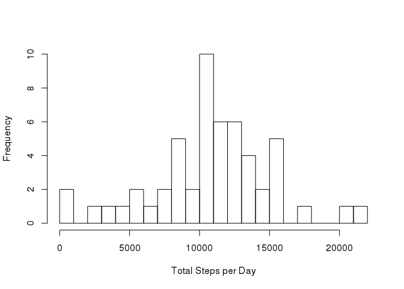

```r
h<-hist(stepsPerDay$TotalSteps,breaks=20,
        xlab="Total Steps per Day" ,main=""
      )
```

### Calculate mean and median total steps per day

```r
stats<-summary(stepsPerDay$TotalSteps)
```

## What is the average daily activity pattern?

### Create new averages by intervals

```r
stepsPerInterval <-activity[,mean(steps),by=interval]

#And clean set the column name to something useful

setnames(stepsPerInterval,"V1","MeanSteps")

names(stepsPerInterval)
```

```
## [1] "interval"  "MeanSteps"
```

### Now plots the results

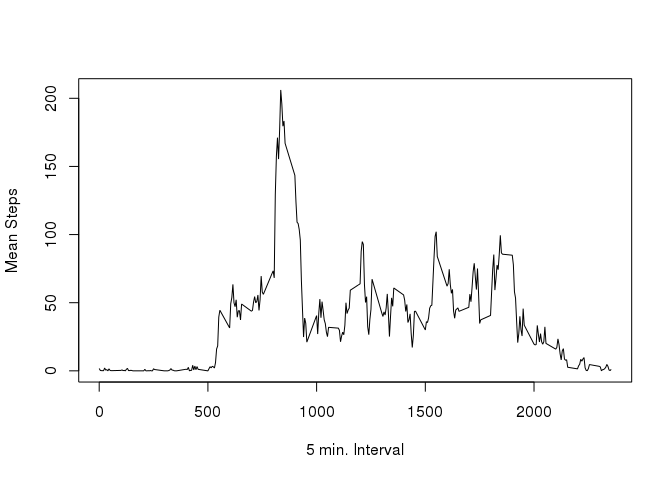

```r
plot(stepsPerInterval$interval,stepsPerInterval$MeanSteps,
     xlab="5 min. Interval", ylab ="Mean Steps",type="l")
```

### Find interval with max. number of steps

```r
maxInterval<-stepsPerInterval$interval[
             which.max(stepsPerInterval$MeanSteps)]
```

The interval with the maximum number of averages steps if 835

## Imputing missing values

### create table of is.na results

```r
counts<-table(is.na(activity$steps))
```

We should check the other column

```r
table(is.na(activity$date))
```

```
##
## FALSE
## 15264
```

```r
table(is.na(activity$interval))
```

```
##
## FALSE
## 15264
```

Here are the steps

1. create a subset with NA values “missing” and a subset that did have values “notMissing”
2. replace steps values in “missing” with means interval values
3. merge the new “missing”" with “notMissing”
4. sort to original order

```r
# step 1
missing<-activity[is.na(steps)]

notMissing<-activity[!is.na(steps)]

#step 2
missing<-merge(missing,stepsPerInterval,by ="interval")

#clean up columns

missing[, steps := NULL ]
```

```
## Empty data.table (0 rows) of 3 cols: interval,date,MeanSteps
```

```r
setnames(missing,"MeanSteps","steps")

#Setp 3

imputed<-rbind(missing,notMissing)

#step 4

imputed<-imputed[order(imputed$date,imputed$interval)]
```

### now lets comare the results to the first section

Calculate new total steps per day

```r
istepsPerDay <-imputed[,sum(steps),by=date]

#And clean set the column name to something useful

setnames(istepsPerDay,"V1","TotalSteps")

names(istepsPerDay)
```

```
## [1] "date"       "TotalSteps"
```

### Now calculate a histogram of the total steps per day but plot later.

```r
hi<-hist(istepsPerDay$TotalSteps,breaks=20,plot=FALSE)
```

### Calculate mean and median total steps per day

```r
istats<-summary(istepsPerDay$TotalSteps)
```

Let plot the histograms together

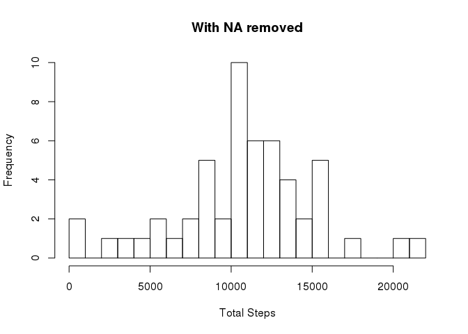

```r
plot(h,xlab="Total Steps",main ="With NA removed")
```

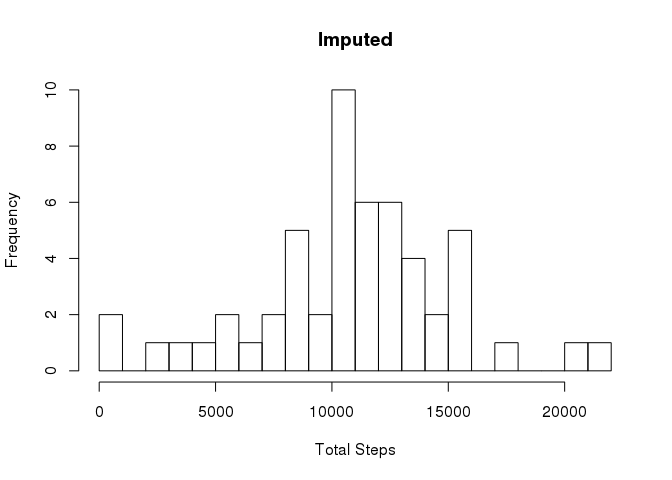

```r
plot(hi,xlab="Total Steps", main ="Imputed")
```

[output not shown]

## Are there differences in activity patterns between weekdays and weekends?

### Starting with data.table “imputed”

### create a new column “weekday” that is TRUE for weekdays and FALSe for weekends

```r
imputed[, weekday :=
          as.factor(!weekdays(as.Date(imputed$date))
          %in% c("Sunday"  ,"Saturday"))
      ]
```

```
##        interval       date steps weekday
##     1:        0 2012-10-02     0    TRUE
##     2:        5 2012-10-02     0    TRUE
##     3:       10 2012-10-02     0    TRUE
##     4:       15 2012-10-02     0    TRUE
##     5:       20 2012-10-02     0    TRUE
##    ---
## 15260:     2335 2012-11-29     0    TRUE
## 15261:     2340 2012-11-29     0    TRUE
## 15262:     2345 2012-11-29     0    TRUE
## 15263:     2350 2012-11-29     0    TRUE
## 15264:     2355 2012-11-29     0    TRUE
```

```r
head(imputed)
```

```
##    interval       date steps weekday
## 1:        0 2012-10-02     0    TRUE
## 2:        5 2012-10-02     0    TRUE
## 3:       10 2012-10-02     0    TRUE
## 4:       15 2012-10-02     0    TRUE
## 5:       20 2012-10-02     0    TRUE
## 6:       25 2012-10-02     0    TRUE
```

And now for the big plot

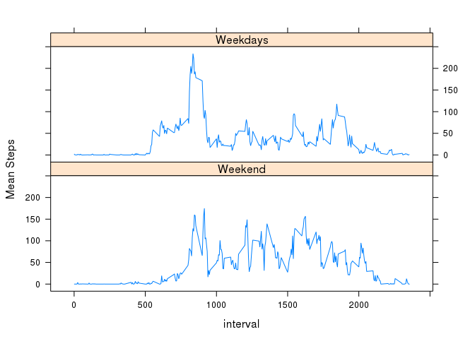

```r
intervalWeedayMeans<-imputed[,mean(steps),by=.(interval,weekday)]


xyplot(intervalWeedayMeans$V1~ intervalWeedayMeans$interval |
        intervalWeedayMeans$weekday, type="l",layout=c(1,2) ,
        xlab="interval" , ylab= "Mean Steps",
        strip=strip.custom(factor.levels=c("Weekend","Weekdays"))
       )
```

Created 2015-02-10 by Craig Parman